# Machine Learning Project 3

Isaac Johnson & Jesse DeBolt

2023-04-11

### Setup

```r
library(tidyverse)
library(ggcorrplot)
library(ggplot2)
library(dplyr)
library(tidytext)
library(caret)
library(fastDummies)
library(randomForest)
library(broom)

raw_income = read_csv("openml_1590.csv", na=c("?"))

income2 = read_csv("openml_1590.csv", na=c("?")) %>%
  drop_na() %>%
  mutate(income_above_50k = class==">50K") %>%
  select(-class)

income2$income_above_50k <- as.numeric(factor(income2$income_above_50k, levels = unique(income2$income_above_50k))) - 1

str(income2)
```

```
## tibble [45,222 × 15] (S3: tbl_df/tbl/data.frame)
##  $ age             : num [1:45222] 25 38 28 44 34 63 24 55 65 36 ...
##  $ workclass       : chr [1:45222] "Private" "Private" "Local-gov" "Private" ...
##  $ fnlwgt          : num [1:45222] 226802 89814 336951 160323 198693 ...
##  $ education       : chr [1:45222] "11th" "HS-grad" "Assoc-acdm" "Some-college" ...
##  $ education-num   : num [1:45222] 7 9 12 10 6 15 10 4 9 13 ...
##  $ marital-status  : chr [1:45222] "Never-married" "Married-civ-spouse" "Married-civ-spouse" "Married-civ-spouse" ...
##  $ occupation      : chr [1:45222] "Machine-op-inspct" "Farming-fishing" "Protective-serv" "Machine-op-inspct" ...
##  $ relationship    : chr [1:45222] "Own-child" "Husband" "Husband" "Husband" ...
##  $ race            : chr [1:45222] "Black" "White" "White" "Black" ...
##  $ sex             : chr [1:45222] "Male" "Male" "Male" "Male" ...
##  $ capital-gain    : num [1:45222] 0 0 0 7688 0 ...
##  $ capital-loss    : num [1:45222] 0 0 0 0 0 0 0 0 0 0 ...
##  $ hours-per-week  : num [1:45222] 40 50 40 40 30 32 40 10 40 40 ...
##  $ native-country  : chr [1:45222] "United-States" "United-States" "United-States" "United-States" ...
##  $ income_above_50k: num [1:45222] 0 0 1 1 0 1 0 0 1 0 ...
```

# **EDA**

### Bucket Age

```r
# Bin the 'age' column
income2 <- income2 %>%
  mutate(age_group = case_when(
    age >= 0 & age <= 25 ~ "young",
    age > 25 & age <= 65 ~ "prime",
    age > 65 & age <= 100 ~ "retired"
  )) %>%
    select(-age)

# Reorder the age_group factor levels
income2$age_group <- factor(income2$age_group, levels = c("young", "prime", "retired"))
```

### Bucket Capital gains/loss

```r
#check if factor
class(income2$income_above_50k)
```

```
## [1] "numeric"
```

```r
# Convert 'income_above_50k' to a factor
income2$income_above_50k <- as.factor(income2$income_above_50k)

# Create 'Capital Diff' column and remove 'Capital Gain' and 'Capital Loss' columns
income2 <- income2 %>%
  mutate(capital_diff = `capital-gain` - `capital-loss`) %>%
  select(-`capital-gain`, -`capital-loss`)

# Bin the 'Capital Diff' column
income2 <- income2 %>%
  mutate(capital_diff = case_when(
    capital_diff >= -5000 & capital_diff <= 5000 ~ "Minor",
    capital_diff > 5000 & capital_diff <= 100000 ~ "Major"
  ))
```

### Drop Columns and without pay

```r
income2 <- income2 %>% select(-fnlwgt)

unique(income2$workclass)
```

```
## [1] "Private"          "Local-gov"        "Self-emp-not-inc" "Federal-gov"
## [5] "State-gov"        "Self-emp-inc"     "Without-pay"
```

```r
income2 <- income2 %>%
  filter(workclass != "Without-pay")
```

### Bucket Hours

```r
# Bin 'Hours per Week' column
income2 <- income2 %>%
  mutate(hours_per_week = case_when(
    `hours-per-week` >= 0 & `hours-per-week` <= 32 ~ "part_time",
    `hours-per-week` > 32 & `hours-per-week` <= 40 ~ "full_time",
    `hours-per-week` > 40 & `hours-per-week` <= 100 ~ "overtime"
  )) %>%
    select(-`hours-per-week`)

#Reorder hours per week
income2$hours_per_week <- factor(income2$hours_per_week, levels = c("part_time", "full_time", "overtime"))
```

### Bucket Education

```r
income2 <- income2 %>%
  select(-`education-num`) %>%
  mutate(education = recode(education,
                            "11th" = "School",
                            "9th" = "School",
                            "7th-8th" = "School",
                            "5th-6th" = "School",
                            "10th" = "School",
                            "1st-4th" = "School",
                            "Preschool" = "School",
                            "12th" = "School"
                            ))
```

### Bucket Occupation

```r
# Calculate the count of 'income_above_50k == 1' for each occupation
occupation_order <- income2 %>%
  filter(income_above_50k == 1) %>%
  group_by(occupation) %>%
  summarize(count = n()) %>%
  arrange(-count) %>%
  pull(occupation)

# Reorder the 'occupation' factor levels based on the calculated order
income2$occupation_ordered <- factor(income2$occupation, levels = occupation_order)
```

### Bucket Race

```r
income2 <- income2 %>%
  mutate(race = recode(race,
                       "Black" = "Other",
                       "Asian-Pac-Islander" = "Other",
                       "Amer-Indian-Eskimo" = "Other",
                       "Other" = "Other"
                       ))
```

### Bucket Country

```r
# Replace all countries except the first one with 'Other'
countries <- unique(income2$`native-country`)
income2$`native-country` <- ifelse(income2$`native-country` %in% countries[-1], "Other", income2$`native-country`)
```

### Create dummy variables

```r
income2_dummies <- income2 %>%
  dummy_cols(select_columns = setdiff(names(income2), "income_above_50k"), remove_selected_columns = T)
```

# **PCA**

### Running PCA on the dataset.

```r
pr_income <- prcomp(x = select(income2_dummies, -income_above_50k), scale = T, center = T)

summary(pr_income)
```

[output not shown]

#### Determining how many principal components are needed to explain half the variation

```r
cumulative_proportion <- cumsum(pr_income$sdev^2 / sum(pr_income$sdev^2))

n_components <- min(which(cumulative_proportion >= 0.5))

cat("The number of principal components needed to explain 50% of the variation is", n_components)
```

```
## The number of principal components needed to explain 50% of the variation is 14
```

#### Viewing the loadings of each principal component to see the individual contribution of each predictor variable to each principal component

```r
loadings <- rownames_to_column(as.data.frame(pr_income$rotation)) %>%
select(1:6) %>%
filter(abs(PC1) >= 0.25 | abs(PC2) >= 0.25 | abs(PC3) >= 0.25 | abs(PC4) >= 0.25 | abs(PC5) >= 0.25)

loadings
```

```
##                               rowname         PC1         PC2         PC3
## 1   marital-status_Married-civ-spouse -0.34418496 -0.06431477 -0.03835910
## 2        marital-status_Never-married  0.26495592 -0.08656009  0.20401137
## 3          occupation_Exec-managerial -0.10320820  0.14076596  0.06894791
## 4           occupation_Prof-specialty -0.06703161  0.28754167  0.14064828
## 5                relationship_Husband -0.35817710 -0.11653127 -0.01585353
## 6                          sex_Female  0.28443138  0.25445830 -0.06511170
## 7                            sex_Male -0.28443138 -0.25445830  0.06511170
## 8                native-country_Other  0.02250133 -0.05049685 -0.16386559
## 9        native-country_United-States -0.02250133  0.05049685  0.16386559
## 10                    age_group_young  0.23733271 -0.18925249  0.25132573
## 11                    age_group_prime -0.22611610  0.17958962 -0.26815655
## 12           hours_per_week_full_time  0.04381778 -0.01000509 -0.28355950
## 13 occupation_ordered_Exec-managerial -0.10320820  0.14076596  0.06894791
## 14  occupation_ordered_Prof-specialty -0.06703161  0.28754167  0.14064828
##             PC4          PC5
## 1  -0.021626424  0.025368676
## 2  -0.049808108 -0.097371565
## 3   0.155253781  0.304299009
## 4  -0.319716307 -0.192641115
## 5  -0.022375721  0.003586733
## 6   0.071223711  0.079982610
## 7  -0.071223711 -0.079982610
## 8  -0.312824867  0.200425469
## 9   0.312824867 -0.200425469
## 10 -0.038034470 -0.083240447
## 11  0.048345084  0.059888882
## 12  0.007396254 -0.141820279
## 13  0.155253781  0.304299009
## 14 -0.319716307 -0.192641115
```

#### Viewing the scree plot to determine how many PCs to choose

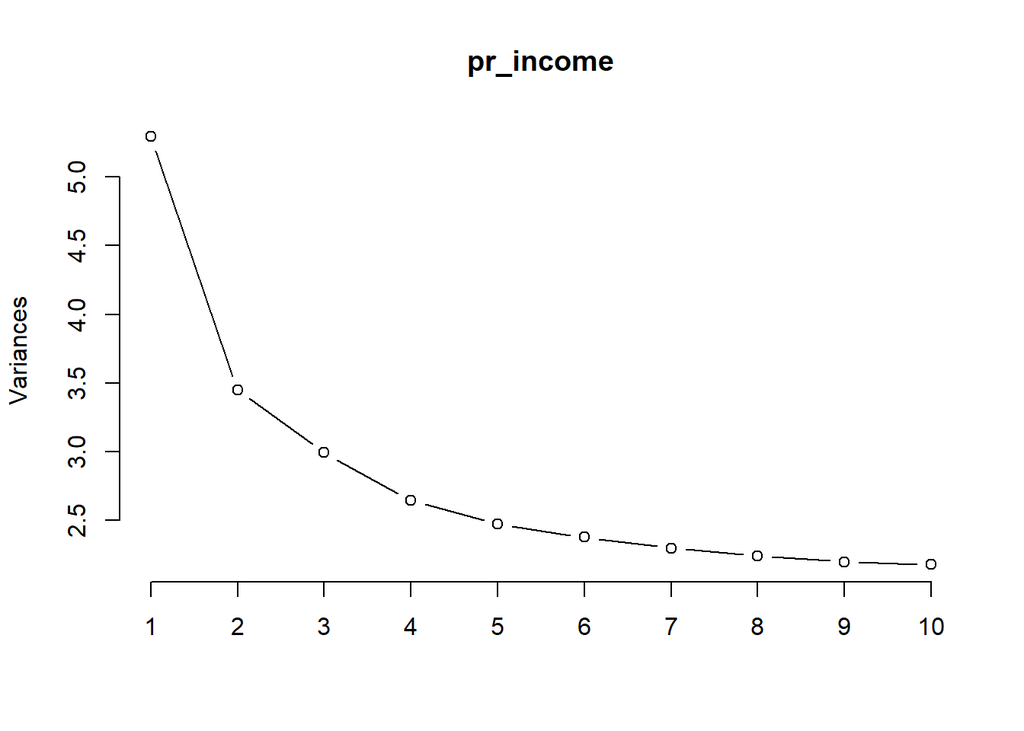

```r
screeplot(pr_income, type = "lines")
```

#### Adding income above 50k back into the data and naming principal components

```r
prc <- bind_cols(select(income2_dummies,income_above_50k),as.data.frame(pr_income$x)) %>%
select(1:6) %>%
  rename(Married_Male = PC1) %>%
  rename(Educated_Professional_Mexican = PC2) %>%
  rename(White_American_With_child = PC3) %>%
  rename(Mature_Single_Female = PC4) %>%
  rename(Black_Professional_American = PC5)
```

## **Density Plots**

### Density of different components by income (Factors 1&2)

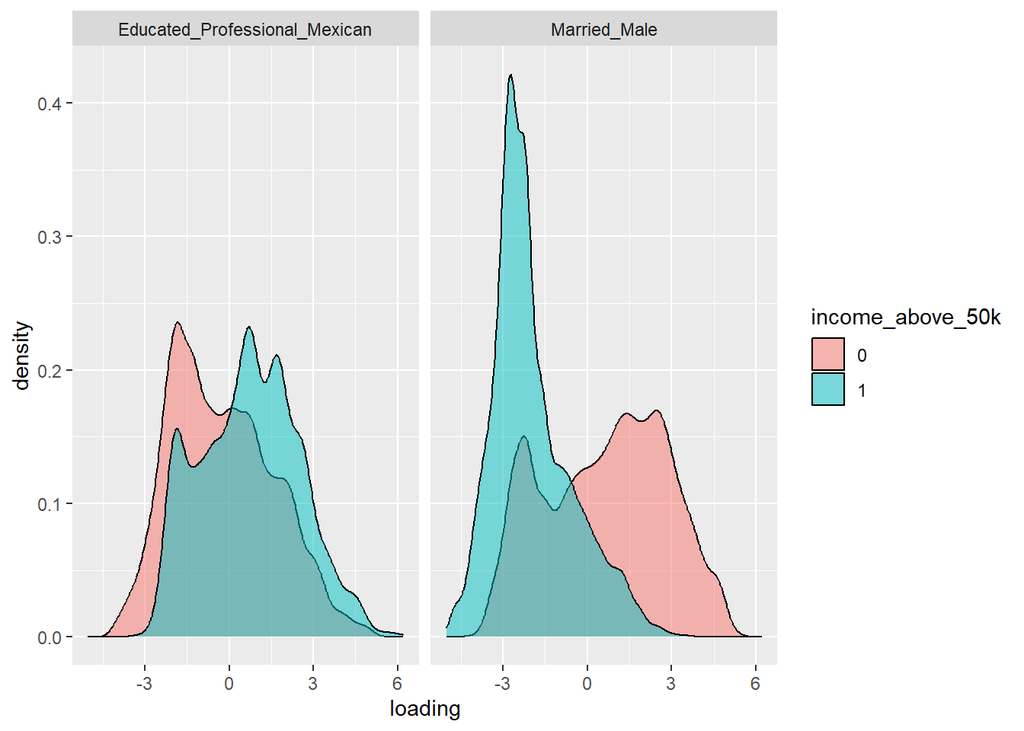

```r
prc %>%
  select(income_above_50k, Married_Male, Educated_Professional_Mexican) %>%
  pivot_longer(cols = -income_above_50k,names_to = "component",values_to = "loading") %>%
ggplot(aes(loading, fill=income_above_50k))+
geom_density(alpha=0.5)+
facet_grid(.~component)
```

### Density of different components by income (Factors 3&4)

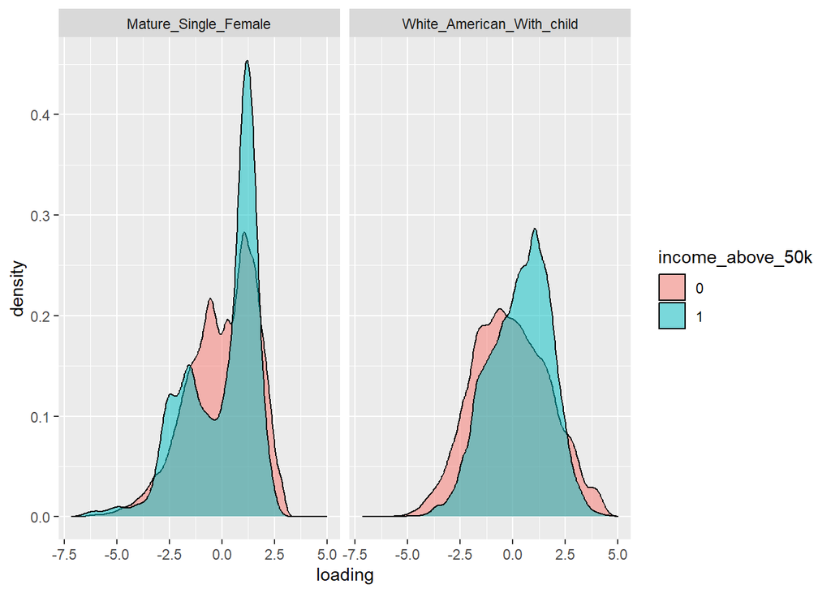

```r
prc %>%
  select(income_above_50k, White_American_With_child, Mature_Single_Female) %>%
  pivot_longer(cols = -income_above_50k,names_to = "component",values_to = "loading") %>%
ggplot(aes(loading, fill=income_above_50k))+
geom_density(alpha=0.5)+
facet_grid(.~component)
```

### Density of different components by income (Factors 4&5)

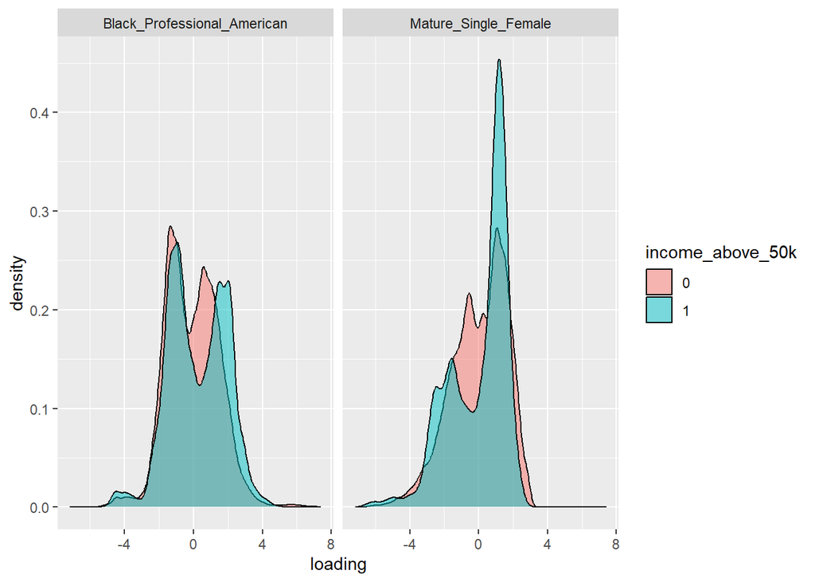

```r
prc %>%
  select(income_above_50k, Mature_Single_Female, Black_Professional_American) %>%
  pivot_longer(cols = -income_above_50k,names_to = "component",values_to = "loading") %>%
ggplot(aes(loading, fill=income_above_50k))+
geom_density(alpha=0.5)+
facet_grid(.~component)
```

# **Modeling**

### Use the top five factors for prediction

```r
set.seed(555)

fit <- train(income_above_50k ~ .,
             data = prc,
             method = "naive_bayes",
             trControl = trainControl(method = "cv"))


confusionMatrix(predict(fit, prc),factor(prc$income_above_50k))
```

```
## Confusion Matrix and Statistics
##
##           Reference
## Prediction     0     1
##          0 30574  4757
##          1  3421  6449
##
##                Accuracy : 0.8191
##                  95% CI : (0.8155, 0.8226)
##     No Information Rate : 0.7521
##     P-Value [Acc > NIR] : < 2.2e-16
##
##                   Kappa : 0.4946
##
##  Mcnemar's Test P-Value : < 2.2e-16
##
##             Sensitivity : 0.8994
##             Specificity : 0.5755
##          Pos Pred Value : 0.8654
##          Neg Pred Value : 0.6534
##              Prevalence : 0.7521
##          Detection Rate : 0.6764
##    Detection Prevalence : 0.7816
##       Balanced Accuracy : 0.7374
##
##        'Positive' Class : 0
##
```

### Use the top two factors for prediction

```r
set.seed(555)

fit <- train(income_above_50k ~ Married_Male+Educated_Professional_Mexican,
             data = prc,
             method = "naive_bayes",
             trControl = trainControl(method = "cv"))


confusionMatrix(predict(fit, prc),factor(prc$income_above_50k))
```

```
## Confusion Matrix and Statistics
##
##           Reference
## Prediction     0     1
##          0 31106  5087
##          1  2889  6119
##
##                Accuracy : 0.8235
##                  95% CI : (0.82, 0.827)
##     No Information Rate : 0.7521
##     P-Value [Acc > NIR] : < 2.2e-16
##
##                   Kappa : 0.4935
##
##  Mcnemar's Test P-Value : < 2.2e-16
##
##             Sensitivity : 0.9150
##             Specificity : 0.5460
##          Pos Pred Value : 0.8594
##          Neg Pred Value : 0.6793
##              Prevalence : 0.7521
##          Detection Rate : 0.6882
##    Detection Prevalence : 0.8007
##       Balanced Accuracy : 0.7305
##
##        'Positive' Class : 0
##
```

# Further exploring with PCs and models

### Creating a model with hand selected features based on principal components.

```r
income3 <- income2_dummies %>%
  select("income_above_50k", "sex_Male", "occupation_Prof-specialty", "education_School", "native-country_United-States", "marital-status_Married-civ-spouse", "education_Masters", "education_Bachelors",  "race_White", "occupation_ordered_Prof-specialty", "age_group_prime", "occupation_Exec-managerial", "occupation_ordered_Exec-managerial")
```

### Creating prc sets with larger selections

```r
prc10 <- bind_cols(select(income2_dummies,income_above_50k),as.data.frame(pr_income$x)) %>%
select(1:11)

prc25 <- bind_cols(select(income2_dummies,income_above_50k),as.data.frame(pr_income$x)) %>%
select(1:26)

prcAll <- bind_cols(select(income2_dummies,income_above_50k),as.data.frame(pr_income$x))
```

### Attempting gradiant boosting on hand selected features

```r
fit <- train(income_above_50k ~ .,
             data = income3,
             method = "gbm",
             trControl = trainControl(method = "cv"))
```

### Gradiant boosting results

```r
confusionMatrix(predict(fit, income3),factor(income3$income_above_50k))
```

```
## Confusion Matrix and Statistics
##
##           Reference
## Prediction     0     1
##          0 31542  5606
##          1  2453  5600
##
##                Accuracy : 0.8217
##                  95% CI : (0.8181, 0.8252)
##     No Information Rate : 0.7521
##     P-Value [Acc > NIR] : < 2.2e-16
##
##                   Kappa : 0.4721
##
##  Mcnemar's Test P-Value : < 2.2e-16
##
##             Sensitivity : 0.9278
##             Specificity : 0.4997
##          Pos Pred Value : 0.8491
##          Neg Pred Value : 0.6954
##              Prevalence : 0.7521
##          Detection Rate : 0.6978
##    Detection Prevalence : 0.8218
##       Balanced Accuracy : 0.7138
##
##        'Positive' Class : 0
##
```

### Running various models

```r
set.seed(555)

fit <- train(income_above_50k ~ .,
             data = prc25,
             method = "knn",
             trControl = trainControl(method = "cv"))

confusionMatrix(predict(fit, prc25), factor(prc25$income_above_50k))
```

```
## Confusion Matrix and Statistics
##
##           Reference
## Prediction     0     1
##          0 31594  4248
##          1  2401  6958
##
##                Accuracy : 0.8529
##                  95% CI : (0.8496, 0.8562)
##     No Information Rate : 0.7521
##     P-Value [Acc > NIR] : < 2.2e-16
##
##                   Kappa : 0.5825
##
##  Mcnemar's Test P-Value : < 2.2e-16
##
##             Sensitivity : 0.9294
##             Specificity : 0.6209
##          Pos Pred Value : 0.8815
##          Neg Pred Value : 0.7435
##              Prevalence : 0.7521
##          Detection Rate : 0.6990
##    Detection Prevalence : 0.7929
##       Balanced Accuracy : 0.7751
##
##        'Positive' Class : 0
##
```

Note: The above chunk was used for multiple models, changing out data and method, results were recorded below.

# **Overall Results:**

prc with 2pc NB: kappa=.4935, Accuracy=.8235  
prc with 2pc KNN: kappa=.5659, Accuracy=.8478

prc with 5pc NB: kappa=.4946, Accuracy=.8191  
prc with 5pc KNN: kappa=.5708, Accuracy=.8496

prc with 10pc NB: kappa=.5103, Accuracy=.8200  
prc with 10pc KNN: kappa=.5837, Accuracy=.8541

prc with 25pc NB: kappa=.5377, Accuracy=.8281  
prc with 25pc KNN: kappa=.5825, Accuracy=.8529

prc with all 71pc KNN: kappa=.5895, Accuracy=.8549

### Plotting of the results

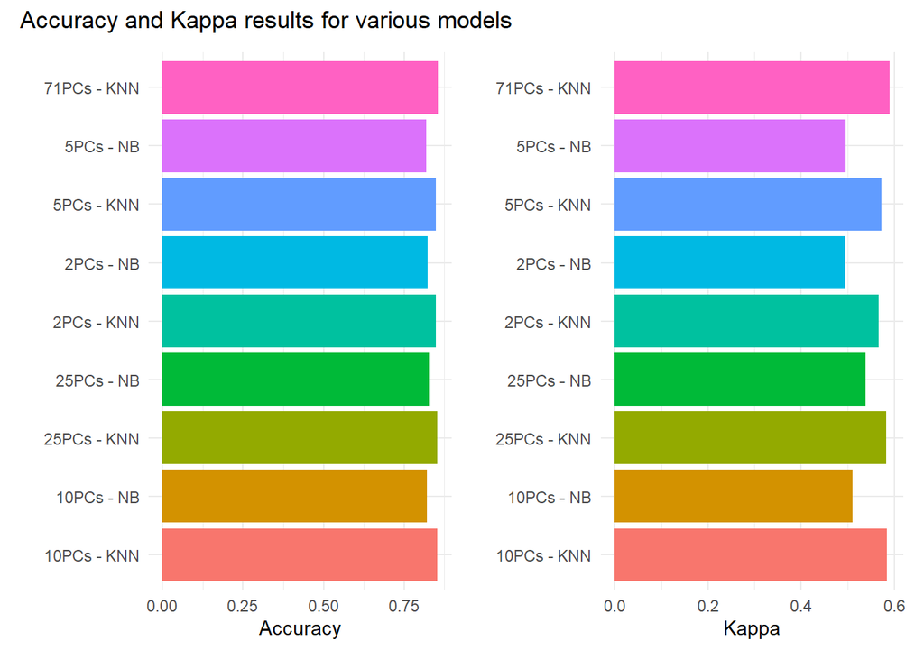

```r
results <- read.csv('results.csv')

accuracyPlot <- results %>%
ggplot(aes(x = X, y = Accuracy, fill = X)) +
  geom_col() +
  coord_flip() +
  labs(x = "", y = "Accuracy") +
  theme_minimal()+
  theme(legend.position="none")

kappaPlot <- results %>%
ggplot(aes(x = X, y = Kappa, fill = X)) +
  geom_col() +
  coord_flip() +
  labs(x = "", y = "Kappa") +
  theme_minimal()+
  theme(legend.position="none")


library(patchwork)

accuracyPlot + kappaPlot + plot_annotation(
  title = "Accuracy and Kappa results for various models"
)
```

# **Questions & Answers**

#### Run PCA on the dataset. How many principal components do you need to explain half the variation?

**Answer:**The number of principal components needed to explain 50% of the variation is 14.

#### Can you give some interpretation of the principal components?

**Answer:**  
pc1=Married-Male,  
pc2=Educated-Professional-Mexican,  
pc3=White-American-With_child,  
PC4=Mature-Single-Female,  
pc5=Black-Professional-American

#### Look at the scree plot. How many PCs would you choose based on that?

**Answer:**We would choose five PCs since it appears as though that is a good representation of the ‘elbow’.

#### Are the first few Principal Components good predictors of income_above_50k?

**Answer:** With 82% accuracy we can say that we are somewhat accurate in predicting if income is above $50k. When reviewing the truth matrix we can see that we are good at predicting true negatives, however predicting true positives are not as good.

#### How well can you predict income_above_50k using the first 5 or 6 principal components? How about only the first 2?

**Answer:** For the first five or six principals we saw above that we are somewhat accurate in predicting if income is above $50k. For the first two principal components we can see that we have an 82% accuracy, which means we are somewhat accurate in predicting if income is above $50k. When reviewing the truth matrix we can see that we are slightly better at predicting true negatives, however predicting true positives are slightly better with the first five principal components.

#### Using any and all techniques we have learned, build the best predictive model for income_above_50k that you can. What are your best features? What model did you use? What interpretations can you draw?

**Answer:**It was really hard to predict income. None of the variables seemed to have a large effect on being able to accurately predict income. We tried PCA, Kmeans clusters, feature engineering, binning the variables, etc… The model only got worse. We determined that the best model was when we used the top 10 principal components with the KNN method. Using all 71 principal component did result in a slightly better kappa and accuracy, but the length of time to run the model was much longer and not worth the added effort. Also the dataset was pretty imbalanced since about 75% of the data was income below 50k.

#### What metric can you use to assess model performance? Why is that a good choice of metric in this case?

**Answer:**Each of the different metrics have their strengths and weaknesses, so it’s important that we understand those differences before choosing the one that fits our needs.  
Accuracy is a useful metric when the classes are balanced, but it can be misleading when dealing with imbalanced datasets which our dataset is.  
Kappa is a measure of agreement between predicted and observed categorical outcomes, accounting for the agreement that would occur by chance. Kappa is less sensitive to class imbalance compared to accuracy and is useful when the dataset is imbalanced.  
AUC-ROC (Area Under the Receiver Operating Characteristic Curve): AUC-ROC measures the ability of the model to distinguish between the classes. An AUC with a value of 1 indicates a perfect model, and 0.5 indicates that the model is no better than random guessing. AUC-ROC is robust against class imbalance and is particularly useful for binary classification problems.  
The F1 score is the harmonic mean of precision and recall. It is useful when the class imbalance is present and when false positives and false negatives carry different costs, which not knowing how our model will be used not sure of what those costs would be.

Overall, we decided to use kappa and accuracy for our measurement since our data is unbalanced. Since we are just measuring income, it doesn’t seem that any imprecision in the model has much of a cost.

#### What are some key insights you found through your analysis?

**Answer:** Ultimately, it seems that there is some X factor on why some people were able to make a different income than others. Why would some with just a High school education make over 50k as a similar total number of people with some college or even a bachelors degree. The overall number of people in both income groups was different, but why are some people able to make over 50k and others aren’t considering based on these variables the have very similar backgrounds or history? Our only assumption is that the data is too unbalanced to provide accurate predictions. This can be easily seen from the ratio of men to women, as well as how much less data is available within the income above 50K observations. We did some basic hyperparameter adjustments on some of the models, but in the end opted to work with the defaults for ease and quickness.

# Grading

10 pts PCA  
* analysis and interpretation of factor loadings  
* discussion of scree plot and/or analysis of some density plots of PCs  
* meaningful interpretation / discussion of conclusions

10 pts k-means  
* discussion for choosing number of clusters  
* analysis of cluster centers  
* bivariate chart(s) against meaningful variables and/or analysis of density plots  
* meaningful interpretation / discussion of conclusions

10 pts supervised learning  
* feature engineering / selection, whether with PCA or otherwise  
* interpretation of variable importance, coefficients if applicable  
* justification of choice of metric  
* discussion of choice or tuning of hyperparameters, if any  
* meaningful discussion of predictive power and conclusions from model